# Human Activity Recognition : Practical Machine Learning (Coursera)

Debjyoti Paul

Sunday, December 21, 2014

# Abstract

In this project, a predictive system has been modelled using Random Forest to infer on the qualitative aspect of Human Activity Recognition using weight lifting exersise dataset (Velloso et al. 2013). It will help the users to have a real time feedback on the quality of excetution of the exersise based on sensor data.

# Data

This project is based on the Weight Lifting Exercises(WLE) Dataset from Human Activity Recognition project of GroupWare http://groupware.les.inf.puc-rio.br/har.

# Initilization

The seed is set to enable reproduction. Libraries required are loaded

```r
set.seed(111)
library(caret)
library(randomForest)
```

# Getting Data

The training and testing data are downloaded from the url provided.

```r
tr.file <- 'pml-training.csv'
te.file <- 'pml-test.csv'
tr.url  <- 'http://d396qusza40orc.cloudfront.net/predmachlearn/pml-training.csv'
te.url  <- 'http://d396qusza40orc.cloudfront.net/predmachlearn/pml-testing.csv'

download.file(tr.url, tr.file, method='auto')
download.file(te.url, te.file, method='auto')
```

# Cleaning Data

```r
trdata = read.csv(file=tr.file, header=TRUE, sep=",")
tedata = read.csv(file=te.file, header=TRUE, sep=",")
trdata = subset( trdata, select = -1 )
tedata = subset( tedata, select = -1 )
nums <- sapply(trdata, is.numeric)
cleandata <- trdata[,nums]
training <- cleandata[ , colSums(is.na(cleandata)) == 0]
```

# Partition Data

The cleaned data is partitioned into Training and Testing dataset.

```r
trainingIndex  <- createDataPartition(trdata$classe, p=.75, list=FALSE)
trainData <- training[ trainingIndex,]
testData  <- training[-trainingIndex,]
```

# Training

The predctive model is trained using the training data.

## Method

The **Random Forests** method (Breiman 2001), which applies bagging to tree learners. The **Bootstap Aggregating** (**bagging**) method is described in (Breiman 1996)

## Train

The model is trained using **train** function. The “**method = “rf”**” specifies the random forest method.

```r
modFit <- train(trdata[trainingIndex,]$classe ~ .,method = "rf", data = trainData)
```

# Result

The predictive model after training and the Training result

```r
modFit
```

```
## Random Forest
##
## 14718 samples
##    54 predictor
##     5 classes: 'A', 'B', 'C', 'D', 'E'
##
## No pre-processing
## Resampling: Bootstrapped (25 reps)
##
## Summary of sample sizes: 14718, 14718, 14718, 14718, 14718, 14718, ...
##
## Resampling results across tuning parameters:
##
##   mtry  Accuracy   Kappa      Accuracy SD   Kappa SD
##    2    0.9944169  0.9929370  0.0010851613  0.001373928
##   28    0.9981864  0.9977054  0.0007972433  0.001010032
##   55    0.9965977  0.9956958  0.0014113939  0.001786594
##
## Accuracy was used to select the optimal model using  the largest value.
## The final value used for the model was mtry = 28.
```

```r
print(modFit$finalModel)
```

```
##
## Call:
##  randomForest(x = x, y = y, mtry = param$mtry)
##                Type of random forest: classification
##                      Number of trees: 500
## No. of variables tried at each split: 28
##
##         OOB estimate of  error rate: 0.06%
## Confusion matrix:
##      A    B    C    D    E  class.error
## A 4185    0    0    0    0 0.0000000000
## B    1 2846    1    0    0 0.0007022472
## C    0    3 2564    0    0 0.0011686794
## D    0    0    2 2409    1 0.0012437811
## E    0    0    0    1 2705 0.0003695492
```

[figure not shown]

An instance of a tree in the random forest.

```r
getTree( modFit$finalModel , k = 3)
```

[output not shown]

[output cut: 543 more lines]

Confusion matrix and statistics depicting the Performance of the model on the testing data(testData)

```r
pred <- predict( modFit, newdata = testData )
confusionMatrix(pred,trdata[-trainingIndex,]$classe)
```

```
## Confusion Matrix and Statistics
##
##           Reference
## Prediction    A    B    C    D    E
##          A 1395    0    0    0    0
##          B    0  949    1    0    0
##          C    0    0  854    1    0
##          D    0    0    0  803    0
##          E    0    0    0    0  901
##
## Overall Statistics
##
##                Accuracy : 0.9996
##                  95% CI : (0.9985, 1)
##     No Information Rate : 0.2845
##     P-Value [Acc > NIR] : < 2.2e-16
##
##                   Kappa : 0.9995
##  Mcnemar's Test P-Value : NA
##
## Statistics by Class:
##
##                      Class: A Class: B Class: C Class: D Class: E
## Sensitivity            1.0000   1.0000   0.9988   0.9988   1.0000
## Specificity            1.0000   0.9997   0.9998   1.0000   1.0000
## Pos Pred Value         1.0000   0.9989   0.9988   1.0000   1.0000
## Neg Pred Value         1.0000   1.0000   0.9998   0.9998   1.0000
## Prevalence             0.2845   0.1935   0.1743   0.1639   0.1837
## Detection Rate         0.2845   0.1935   0.1741   0.1637   0.1837
## Detection Prevalence   0.2845   0.1937   0.1743   0.1637   0.1837
## Balanced Accuracy      1.0000   0.9999   0.9993   0.9994   1.0000
```

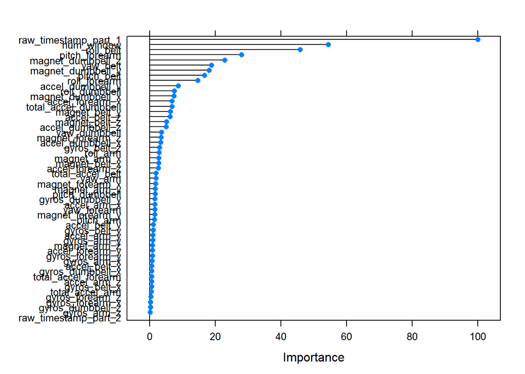

```r
plot( varImp(modFit) )
```

References

Breiman, Leo. 1996. “Bagging Predictors.” *Machine Learning* 24 (2). Springer: 123–40. doi:10.1007%2FBF00058655.

———. 2001. “Random Forests.” *Machine Learning* 45 (1). Springer: 5–32. doi:10.1023%2FA%3A1010933404324.

Velloso, Eduardo, Andreas Bulling, Hans Gellersen, Wallace Ugulino, and Hugo Fuks. 2013. “Qualitative Activity Recognition of Weight Lifting Exercises.” In *Proceedings of the 4th Augmented Human International Conference*, 116–23. ACM.